# Working with Adjusted Print Run Figures

First we will import the data.

```r
#Get data

work <- mpce %>% fetch_table("work")
edition <- mpce %>% fetch_table("edition")
order <- mpce %>% fetch_table("stn_order")
transaction <- mpce %>% fetch_table("stn_transaction")

adjustment <- readxl::read_excel("data/Book_adjustments_19102019.xlsx") %>%
  pivot_longer(
    cols = starts_with("17"),
    names_to = "year",
    values_to = "total_number_of_volumes",
    values_drop_na = T
  ) %>%
  mutate(year = as.numeric(year)) %>%
  group_by(edition, year) %>%
  summarise(total_number_of_volumes = sum(total_number_of_volumes, na.rm=FALSE)) %>%
  ungroup() %>%
  rename(edition_code = edition) %>%
  mutate(
    direction = 0
  )
```

# Balancing the books

Then we need to complete the data. What we want is a decent estimate of how many volumes were printed for each. There are basically three cases: * Books whose recorded figures are trustworthy * Those whose figures have been adjusted based on surrounding evidence * Those which have no print-run data, whose print runs we will estimate from sales figures

This has been a problem on prior analyses, because when we simply add up the data for the STN editions, the books don’t balance.

First we filter out all the non-STN editions, and all of the ‘neutral’ transactions.In order to combine this data with the adjusted data, we need to sum the transaction types by year. We also need to deduct any returns from the out-transaction total.

There was one edition where Simon requested we replace the print-run figures rather than adding missing data. But it turns out there were no print-run figures in the underlying data anyway:

```r
filter(transaction, edition_code == 'bk0000920', str_detect(transaction_description, 'printing')) %>%
  select(edition_code, transaction_description, total_number_of_volumes)
```

| edition_code | transaction_description | total_number_of_volumes |
| --- | --- | --- |

This simplifies the task of incorporating the spreadsheet, and estimating a print run for all editions without printing data.

```r
# Which editions are we interested in?
stn_edition_types <- c("STN editions", "Livres en Société: STN joint editions", "Commissioned STN edition")

# Combine raw with adjusted figures
stn_transaction <- transaction %>%
  # Just keep in- and out-transactions from STN editions
  left_join(select(edition, edition_code, edition_type),
            by = "edition_code") %>%
  filter(edition_type %in% stn_edition_types,
         direction != 3) %>%
  select(-edition_type) %>%
  left_join(order, by = 'order_code') %>%
  mutate(date = as.integer(date)) %>%
  # Add a new transaction direction seperating printings from other in-transactions
  mutate(
    direction = if_else(str_detect(transaction_description, "printing"), 0L, direction)
  ) %>%
  # Now all printings have direction '0'
  # Now aggregate by edition, year and direction
  mutate(year = year(ymd(date))) %>%
  group_by(edition_code, year, direction) %>%
  # Now aggregate
  summarise(total_number_of_volumes = sum(total_number_of_volumes, na.rm = T)) %>%
  ungroup() %>%
  # Add in the adjustment spreadsheet
  bind_rows(adjustment)
```

```
 4 failed to parse.
```

```r
stn_transaction %>%
  group_by(edition_code, direction) %>%
  summarise(sum = sum(total_number_of_volumes))
```

| edition_code | direction | sum |
| --- | --- | --- |
| bk0000015 | 0 | 1020 |
| bk0000015 | 2 | -1002 |
| bk0000069 | 1 | 44 |
| bk0000069 | 2 | -3874 |
| bk0000070 | 1 | 21 |
| bk0000070 | 2 | -2141 |
| bk0000091 | 0 | 89 |
| bk0000091 | 2 | -62 |
| bk0000094 | 0 | 1542 |
| bk0000094 | 1 | 410 |

[output cut: 613 more lines]

Now let us calculate the most likely year that these books were printed, and a likely print run. The most likely year is the actualyear of the edition, the date of the first transaction, or the imprint year, in that order. The print run is calculated as equal to the net transactions (Out - In), rounded up to the nearest multiple of 100. (This factor of 100 can easily be altered)

```r
# Calculate the best year for each edition (for adding print-runs to unknowns)
best_year <- transaction %>%
  # Get year of first transaction for each edition
  left_join(order, by = "order_code") %>%
  mutate(date = year(ymd(date))) %>%
  group_by(edition_code) %>%
  arrange(date) %>%
  summarise(date = head(date, 1)) %>%
  # Add in edition data
  left_join(edition, by = "edition_code") %>%
  filter(edition_type %in% stn_edition_types) %>%
  transmute(edition_code = edition_code,
            imprint_publication_years = na_if(imprint_publication_years, ""),
            actual_publication_years = na_if(actual_publication_years, ""),
            best_year = coalesce(
              str_trunc(actual_publication_years, 4, ellipsis = "") %>% as.numeric(),
              date,
              str_trunc(imprint_publication_years, 4, ellipsis = "") %>% as.numeric()
            )
  )
```

```
 11 failed to parse.
```

```r
# Get all books that have no print-run data
no_data <- stn_transaction %>%
  group_by(edition_code, direction) %>%
  summarise(sum = sum(total_number_of_volumes)) %>%
  pivot_wider(names_from = direction, values_from = sum) %>%
  filter(is.na(`0`)) %>%
  mutate(printed = ceiling(-sum(`1`, `2`, na.rm = T)/100)*100)
```

Among these books without print runs, there are several that seem not to have been printed by the STN. The calculated print run is 0 or less than zero, because the number of copies that were brought in exceed the number of copies sold. Most of them are ‘joint editions’, and were presumably printed by the STN’s partners. There are a couple of exceptions. `bk0001998` has been classified as a ‘Commissioned Edition’, but the events recorded in the database suggest that may actually have been manufactured by a one Samuel Fauche and merely sold by the STN. Likewise `bk0002298` appears to have really been produced by Charles Bosset, while `bk0002395` and `bk0002452` seems really to have been manufactured by Jonas Fauche. Thus it seems correct to exclude these books from our estimates.

```r
no_data %>%
  select(-`0`) %>%
  filter(printed <= 0) %>%
  left_join(
    select(edition, edition_code, edition_type, full_book_title),
    by = "edition_code"
  ) %>%
  mutate(full_book_title = str_trunc(full_book_title, 25))
```

| edition_code | 2 | 1 | printed | edition_type | full_book_title |
| --- | --- | --- | --- | --- | --- |
| bk0000954 | -479 | 521 | 0 | Livres en Société: STN joint editions | Observations sur la co... |
| bk0001292 | -699 | 816 | -100 | Livres en Société: STN joint editions | Maître de la langue al... |
| bk0001490 | -3078 | 3350 | -200 | Livres en Société: STN joint editions | Incas (les), ou la des... |
| bk0001591 | -909 | 978 | 0 | Livres en Société: STN joint editions | Voyages autour du mond... |
| bk0001967 | -1556 | 1686 | -100 | Livres en Société: STN joint editions | Mon Bonnet de nuit |
| bk0001998 | -12 | 14 | 0 | Commissioned STN edition | Cinq catéchismes pour ... |
| bk0002034 | -316 | 337 | 0 | Livres en Société: STN joint editions | Correspondance de Fern... |
| bk0002298 | -225 | 526 | -300 | STN editions | Jardin (le) potager mi... |
| bk0002395 | -19 | 25 | 0 | STN editions | Mémoires à consulter p... |
| bk0002400 | -456 | 557 | -100 | Livres en Société: STN joint editions | Mémoires de M. le comt... |

[output cut: 4 more lines]

So now it is time to join these estimates to the rest of the data.

```r
final_numbers <- no_data %>%
  # Filter out editions the STN probably didn't print
  filter(printed > 0) %>%
  # Get the best year
  left_join(best_year, by = "edition_code") %>%
  # Just keep key variables and reformat
  select(edition_code, year = best_year, total_number_of_volumes = printed) %>%
  # Add in direction coding
  mutate(direction = 0) %>%
  # Join to the rest of the data
  bind_rows(stn_transaction)
```

Now we have reasonably reliable print runs for all STN editions. Do the books now balance?

```r
final_numbers %>%
  group_by(direction) %>%
  summarise(volumes = sum(total_number_of_volumes)) %>%
  mutate(direction = recode(direction, `0` ='printed', `1` = 'other in', `2` = 'out')) %>%
  add_row(direction = 'TOTAL', volumes = sum(final_numbers$total_number_of_volumes))
```

| direction | volumes |
| --- | --- |
| printed | 631915 |
| other in | 66664 |
| out | -598965 |
| TOTAL | 99614 |

# Estimating Paper Requirements

**NB:** There is some uncertainty about how to interpret the pagination records. But this will only result in a sheet or two’s difference here or there. We can revist to tweak the final numbers before publication.

```r
full_sheets_data <- final_numbers %>%
  left_join(
    select(edition, edition_code, pages, edition, number_of_volumes),
    by = "edition_code"
  ) %>%
  ungroup() %>%
  mutate(
    calculated_pages = sum_pages(pages),
    leaves = str_replace(edition, "[fF]", "2"),
    leaves = str_remove_all(leaves, "\\D"),
    leaves = as.numeric(leaves),
    calculated_sheets = calculate_sheets(calculated_pages, leaves),
    sheets_transacted = calculated_sheets * total_number_of_volumes / number_of_volumes,
    direction = as_factor(direction) %>% recode(`0` = "Printing", `1` = "Other In", `2` = "Out")
  ) %>%
  select(
    edition_code,
    year,
    direction,
    pagination = pages,
    calculated_pages,
    edition,
    leaves,
    calculated_sheets,
    vols_per_copy = number_of_volumes,
    vols_transacted = total_number_of_volumes,
    sheets_transacted
  )
```

# Have a little look…

So we have completely revised the data now, trying to account for the print runs, and all other transactions. Let’s have a quick look at how it all works now.

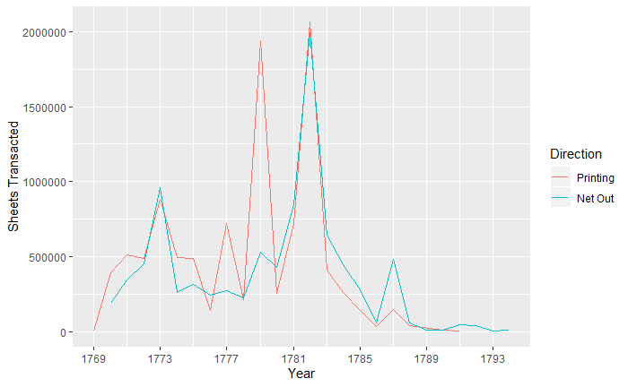

```r
full_sheets_data %>%
  mutate(direction = fct_collapse(direction, Printing = c("Printing"), `Net Out` = c("Other In", "Out"))) %>%
  group_by(direction, year) %>%
  summarise(sheets_transacted = sum(sheets_transacted, na.rm = T)) %>%
  mutate(sheets_transacted = abs(sheets_transacted)) %>%
  ggplot(aes(year, sheets_transacted, colour = direction)) +
  geom_line() +
  scale_x_continuous(
    breaks = seq(1769, 1793, 4),
    minor_breaks = seq(1771, 1793, 4)
  ) +
  labs(
    x = "Year",
    y = "Sheets Transacted",
    colour = "Direction"
  )
```

# What to do with the gaps?

Now the old issue raises its head once more—what to do about the gaps in the data? Let’s try to get a sense of the problem.

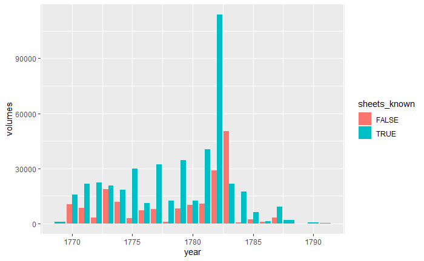

```r
full_sheets_data %>%
  filter(direction == "Printing") %>%
  group_by(year, sheets_known = !is.na(calculated_sheets)) %>%
  summarise(transactions = n(),
            volumes = sum(vols_transacted)) %>%
  ggplot(aes(year, volumes, fill = sheets_known)) +
  geom_col(position = "dodge")
```

For the books where we do know the number of sheets, is the mean a good approximation of their value? Firstly, for how many books do we know the publishing format?

| leaves | editions |
| --- | --- |
| 2 | 3 |
| 4 | 18 |
| 8 | 145 |
| 12 | 50 |
| NA | 30 |

Let’s consider average sheets per volume in each format. How much variation is there?

| leaves | mean | median |
| --- | --- | --- |
| 2 | 162.00000 | 162 |
| 4 | 20.64103 | 7 |
| 8 | 16.17419 | 16 |
| 12 | 14.31458 | 16 |

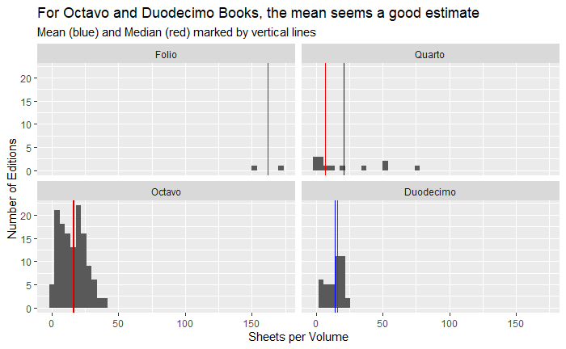

Some books had sheets data manually entered, though the quality of this data is suspect. As discussed in a previous notebook, there appears to be some inconsistency in what was actually entered in the column. But let’s see if we can get some sheets data from there.

```r
full_sheets_data %>%
  select(edition_code, vols_per_copy, leaves, calculated_sheets) %>%
  distinct(edition_code, .keep_all = T) %>%
  filter(is.na(calculated_sheets)) %>%
  left_join(select(edition, edition_code, book_sheets))
```

[output not shown]

| sheet_data | direction | total_vols |
| --- | --- | --- |
| FALSE | Printing | 107702 |
| FALSE | Other In | 4268 |
| FALSE | Out | -74032 |
| TRUE | Printing | 524213 |
| TRUE | Other In | 62396 |
| TRUE | Out | -524933 |

There are still many transactions that have no sheet data attached.About a sixth of the transacted volumes still have no estimate of their paper requirements.

What if we simply took the mean number of sheets per volume for *all* volumes, regardless of format? First let’s look at a histogram:

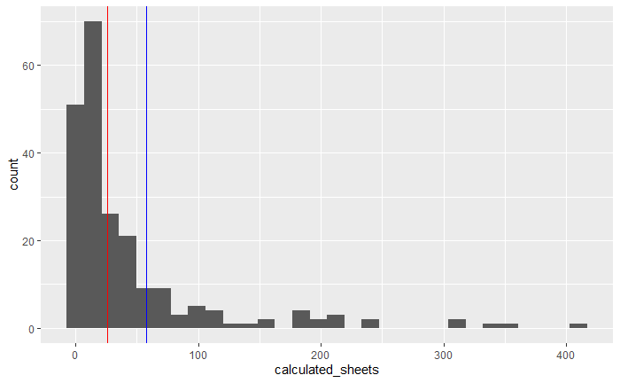

The data is very skewed, so it is difficult to be confident in its central tendency. But perhaps we could assume that massive works, taking tens or hundreds of sheets per volume, would likely have had pagination data available in the porject’s main sources. The 30 books without sheet data probably all fell within the lower band of possible page ranges.

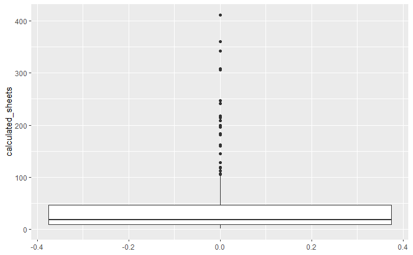

Previously, I had tried to estimate the missing data by comparing the sheets to the number of volumes sold. I thought there might be a correlation—generally, bigger selling titles might have a lesser number of sheets. But the correlation was not so strong and the structure of the data was complex. I think it might be better to estimate the final 30 or so titles by giving a range of possible values, namely the 25% quartile, median and 75% quartile of the calculated sheets for all STN editions.

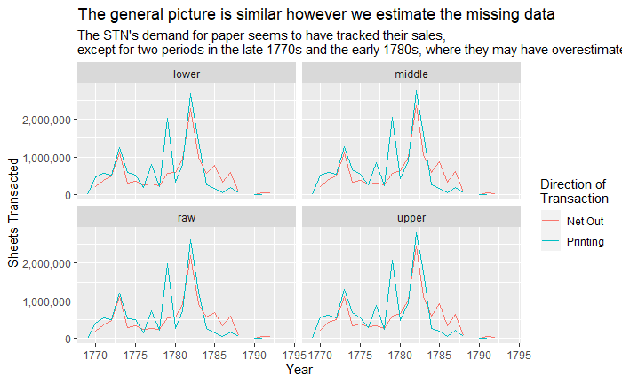